# Food at College

MATH 325

Andrew Seaman

06/27/2025

## Introduction

### Hide

*Click the tabs to read details and see the code.*

### Setup

**Libraries**

These libraries provide the tools necessary for this analysis by way of data sourcing, manipulation, and visualization (see chunk).

```r
library(mosaic)
library(car)
library(DT)
library(pander)
library(readr)
library(tidyverse) # Includes the 'tidyr' package
```

**Data**

The data source is called **Food** (see *Background* for details).

```r
# —————————————
# INSTRUCTIONS:
# —————————————

# From your menu bar (at the top of R-Studio) select:
#   1) "Session -> Set working directory -> To source file location"
#   2) Then play this chunk to get the data into R.


# Data import: source file variables for later construction
file_name <- "food.csv"
file_path <- "../../Data"

# Data import: construct the full file path and import the data
food <- read_csv(file.path(file_path, file_name))

# Note: I used this creative method to import the data (but definitely not neccessary in this context. Kind of clear though).
```

### Comments to Critiquers

If you want to give your critiquers some ideas about what you have questions on and would like help with, place those details here.

Notes:

1. I included a section called **“Exploration”** which shows how I navigated the data to determine my research question.
2. The plots at the end of my analysis are more there because I was curious and have less value towards the ultimate goal of this analysis than do the earlier plots.

## Background

### Description

#### Food choices and preferences of college students

Note: this dataset and description come from: © 2020 Kaggle Inc

For further details visit: [Food choices on Kaggle](https://www.kaggle.com/borapajo/food-choices?select=food_coded.csv)

### Data Summary

The **Food** dataset has over 50 columns of data. Click through the tabs below to see summarizations and detail. (Code source: ChatGPT)

#### Hide

*Click the buttons to view the summaries.*

#### 1. Structure

```r
str(food)
```

```
## spc_tbl_ [125 × 59] (S3: spec_tbl_df/tbl_df/tbl/data.frame)
##  $ GPA                            : chr [1:125] "2.4" "3.654" "3.3" "3.2" ...
##  $ weight                         : chr [1:125] "187" "155" "I'm not answering this." "Not sure, 240" ...
##  $ gender                         : chr [1:125] "Male" "Female" "Female" "Female" ...
##  $ breakfast                      : chr [1:125] "Cereal" "Cereal" "Cereal" "Cereal" ...
##  $ calories_chicken               : num [1:125] 430 610 720 430 720 610 610 720 430 430 ...
##  $ calories_day                   : num [1:125] NA 3 4 3 2 3 3 3 NA 3 ...
##  $ comfort_food                   : chr [1:125] "none" "chocolate, chips, ice cream" "frozen yogurt, pizza, fast food" "Pizza, Mac and cheese, ice cream" ...
##  $ comfort_food_reasons           : chr [1:125] "we dont have comfort" "Stress, bored, anger" "stress, sadness" "Boredom" ...
##  $ comfort_food_reasons_coded...9 : num [1:125] 9 1 1 2 1 4 1 1 2 1 ...
##  $ cook                           : num [1:125] 2 3 1 2 1 3 2 3 3 3 ...
##  $ comfort_food_reasons_coded...11: num [1:125] 9 1 1 2 1 4 1 1 2 1 ...
##  $ cuisine                        : num [1:125] NA 1 3 2 2 NA 1 1 1 1 ...
##  $ diet_current                   : chr [1:125] "eat good and exercise" "I eat about three times a day with some snacks. I try to eat healthy but it doesn't always work out that- somet"| __truncated__ "toast and fruit for breakfast, salad for lunch, usually grilled chicken and veggies (or some va…
##  $ diet_current_coded             : num [1:125] 1 2 3 2 2 2 3 1 1 1 ...
##  $ drink                          : chr [1:125] "orange juice" "soda" "orange juice" "soda" ...
##  $ eating_changes                 : chr [1:125] "eat faster" "I eat out more than usual." "sometimes choosing to eat fast food instead of cooking simply for convenience" "Accepting cheap and premade/store bought foods" ...
##  $ eating_changes_coded           : chr [1:125] "worse" "worse" "worse" "worse" ...
##  $ eating_changes_coded1          : num [1:125] 1 2 3 3 4 3 5 5 8 3 ...
##  $ eating_out                     : chr [1:125] "2-3 times" "1-2 times" "1-2 times" "1-2 times" ...
##  $ employment                     : num [1:125] 3 2 3 3 2 3 3 2 2 3 ...
##  $ ethnic_food                    : num [1:125] 1 4 5 5 4 4 5 2 5 5 ...
##  $ exercise                       : num [1:125] 1 1 2 3 1 2 1 2 NA 1 ...
##  $ father_education               : num [1:125] 5 2 2 2 4 1 4 3 5 5 ...
##  $ father_profession              : chr [1:125] "profesor" "Self employed" "owns business" "Mechanic" ...
##  $ fav_cuisine                    : chr [1:125] "Arabic cuisine" "Italian" "italian" "Turkish" ...
##  $ fav_cuisine_coded              : num [1:125] 3 1 1 3 1 6 4 5 1 1 ...
##  $ fav_food                       : num [1:125] 1 1 3 1 3 3 1 1 3 1 ...
##  $ food_childhood                 : chr [1:125] "rice  and chicken" "chicken and biscuits, beef soup, baked beans" "mac and cheese, pizza, tacos" "Beef stroganoff, tacos, pizza" ...
##  $ fries                          : num [1:125] 2 1 1 2 1 1 1 1 1 1 ...
##  $ fruit_day                      : num [1:125] 5 4 5 4 4 2 4 5 4 5 ...
##  $ grade_level                    : num [1:125] 2 4 3 4 4 2 4 2 1 1 ...
##  $ greek_food                     : num [1:125] 5 4 5 5 4 2 5 3 5 5 ...
##  $ healthy_feeling                : num [1:125] 2 5 6 7 6 4 4 3 7 3 ...
##  $ healthy_meal                   : chr [1:125] "looks not oily" "Grains, Veggies, (more of grains and veggies), small protein and fruit with dairy" "usually includes natural ingredients; nonprocessed food" "Fresh fruits& vegetables, organic meats" ...
##  $ ideal_diet                     : chr [1:125] "being healthy" "Try to eat 5-6 small meals a day. While trying to properly distribute carbs, protein, fruits, veggies, and dairy." "i would say my ideal diet is my current diet" "Healthy, fresh veggies/fruits & organic foods" ...
##  $ ideal_diet_coded               : num [1:125] 8 3 6 2 2 2 2 2 6 2 ...
##  $ income                         : num [1:125] 5 4 6 6 6 1 4 5 5 4 ...
##  $ indian_food                    : num [1:125] 5 4 5 5 2 5 5 1 5 4 ...
##  $ italian_food                   : num [1:125] 5 4 5 5 5 5 5 3 5 5 ...
```

[output cut: 68 more lines]

```
##   ..   parents_cook = col_double(),
##   ..   pay_meal_out = col_double(),
##   ..   persian_food = col_double(),
##   ..   self_perception_weight = col_double(),
##   ..   soup = col_double(),
##   ..   sports = col_double(),
##   ..   thai_food = col_double(),
##   ..   tortilla_calories = col_double(),
##   ..   turkey_calories = col_double(),
##   ..   type_sports = col_character(),
##   ..   veggies_day = col_double(),
##   ..   vitamins = col_double(),
##   ..   waffle_calories = col_double()
##   .. )
##  - attr(*, "problems")=<externalptr>
```

#### 2. Head

```r
head(food)
```

```
## # A tibble: 6 × 59
##   GPA   weight       gender breakfast calories_chicken calories_day comfort_food
##   <chr> <chr>        <chr>  <chr>                <dbl>        <dbl> <chr>
## 1 2.4   187          Male   Cereal                 430           NA none
## 2 3.654 155          Female Cereal                 610            3 chocolate, …
## 3 3.3   I'm not ans… Female Cereal                 720            4 frozen yogu…
## 4 3.2   Not sure, 2… Female Cereal                 430            3 Pizza, Mac …
## 5 3.5   190          Female Cereal                 720            2 Ice cream, …
## 6 2.25  190          Female Cereal                 610            3 Candy, brow…
## # ℹ 52 more variables: comfort_food_reasons <chr>,
## #   comfort_food_reasons_coded...9 <dbl>, cook <dbl>,
## #   comfort_food_reasons_coded...11 <dbl>, cuisine <dbl>, diet_current <chr>,
## #   diet_current_coded <dbl>, drink <chr>, eating_changes <chr>,
## #   eating_changes_coded <chr>, eating_changes_coded1 <dbl>, eating_out <chr>,
## #   employment <dbl>, ethnic_food <dbl>, exercise <dbl>,
## #   father_education <dbl>, father_profession <chr>, fav_cuisine <chr>, …
```

#### 3. Summary (numericals)

```r
summary(food)
```

```
##      GPA               weight             gender           breakfast
##  Length:125         Length:125         Length:125         Length:125
##  Class :character   Class :character   Class :character   Class :character
##  Mode  :character   Mode  :character   Mode  :character   Mode  :character
##
##
##
##
##  calories_chicken  calories_day   comfort_food       comfort_food_reasons
##  Min.   :265.0    Min.   :2.000   Length:125         Length:125
##  1st Qu.:430.0    1st Qu.:3.000   Class :character   Class :character
##  Median :610.0    Median :3.000   Mode  :character   Mode  :character
##  Mean   :577.3    Mean   :3.028
##  3rd Qu.:720.0    3rd Qu.:3.000
##  Max.   :720.0    Max.   :4.000
##                   NA's   :19
##  comfort_food_reasons_coded...9      cook       comfort_food_reasons_coded...11
##  Min.   :1.000                  Min.   :1.000   Min.   :1.000
##  1st Qu.:2.000                  1st Qu.:2.000   1st Qu.:2.000
##  Median :2.000                  Median :3.000   Median :2.000
##  Mean   :2.698                  Mean   :2.787   Mean   :2.688
##  3rd Qu.:3.000                  3rd Qu.:3.000   3rd Qu.:3.000
##  Max.   :9.000                  Max.   :5.000   Max.   :9.000
##  NA's   :19                     NA's   :3
##     cuisine      diet_current       diet_current_coded    drink
##  Min.   :1.000   Length:125         Min.   :1.00       Length:125
##  1st Qu.:1.000   Class :character   1st Qu.:1.00       Class :character
##  Median :1.000   Mode  :character   Median :2.00       Mode  :character
##  Mean   :1.389                      Mean   :1.76
##  3rd Qu.:1.000                      3rd Qu.:2.00
##  Max.   :6.000                      Max.   :4.00
##  NA's   :17
##  eating_changes     eating_changes_coded eating_changes_coded1
##  Length:125         Length:125           Min.   : 1.000
##  Class :character   Class :character     1st Qu.: 3.000
##  Mode  :character   Mode  :character     Median : 4.000
##                                          Mean   : 4.552
##                                          3rd Qu.: 5.000
##                                          Max.   :13.000
##
```

[output cut: 73 more lines]

```
##  Min.   :345     Length:125         Min.   :1.000   Min.   :1.000
##  1st Qu.:500     Class :character   1st Qu.:3.000   1st Qu.:1.000
##  Median :500     Mode  :character   Median :4.000   Median :2.000
##  Mean   :555                        Mean   :4.008   Mean   :1.512
##  3rd Qu.:690                        3rd Qu.:5.000   3rd Qu.:2.000
##  Max.   :850                        Max.   :5.000   Max.   :2.000
##
##  waffle_calories
##  Min.   : 575
##  1st Qu.: 900
##  Median : 900
##  Mean   :1073
##  3rd Qu.:1315
##  Max.   :1315
##
```

```r
# Instantiate empty list for variables with factor levels
factor_vars <- c()

# Find columns
for (colname in names(food)) {
  column <- food[[colname]] # grab the column itself

  if (is.factor(column)) {
    # store column names
    factor_vars <- c(factor_vars, colname)
  }
}

# Show table for each variable
for (colname in factor_vars) {
  table(food$colname)
}
```

#### 5. Count NA

```r
colSums(is.na(food))
```

```
##                             GPA                          weight
##                               2                               2
##                          gender                       breakfast
##                               0                               0
##                calories_chicken                    calories_day
##                               0                              19
##                    comfort_food            comfort_food_reasons
##                               1                               1
##  comfort_food_reasons_coded...9                            cook
##                              19                               3
## comfort_food_reasons_coded...11                         cuisine
##                               0                              17
##                    diet_current              diet_current_coded
##                               1                               0
##                           drink                  eating_changes
##                               2                               3
##            eating_changes_coded           eating_changes_coded1
##                               0                               0
##                      eating_out                      employment
##                               0                               9
##                     ethnic_food                        exercise
##                               0                              13
##                father_education               father_profession
##                               1                               3
##                     fav_cuisine               fav_cuisine_coded
##                               2                               0
##                        fav_food                  food_childhood
##                               2                               1
##                           fries                       fruit_day
##                               0                               0
##                     grade_level                      greek_food
##                               0                               0
##                 healthy_feeling                    healthy_meal
##                               0                               1
##                      ideal_diet                ideal_diet_coded
##                               1                               0
##                          income                     indian_food
##                               1                               0
##                    italian_food                  life_rewarding
##                               0                               1
##                  marital_status             meals_dinner_friend
##                               1                               3
##                mother_education               mother_profession
##                               3                               2
##               nutritional_check                   on_off_campus
##                               0                               1
##                    parents_cook                    pay_meal_out
##                               0                               0
##                    persian_food          self_perception_weight
##                               1                               1
##                            soup                          sports
##                               1                               2
##                       thai_food               tortilla_calories
##                               0                               1
##                 turkey_calories                     type_sports
##                               0                              21
##                     veggies_day                        vitamins
##                               0                               0
##                 waffle_calories
##                               0
```

#### 6. All Vars

```r
names(food)
```

```
##  [1] "GPA"                             "weight"
##  [3] "gender"                          "breakfast"
##  [5] "calories_chicken"                "calories_day"
##  [7] "comfort_food"                    "comfort_food_reasons"
##  [9] "comfort_food_reasons_coded...9"  "cook"
## [11] "comfort_food_reasons_coded...11" "cuisine"
## [13] "diet_current"                    "diet_current_coded"
## [15] "drink"                           "eating_changes"
## [17] "eating_changes_coded"            "eating_changes_coded1"
## [19] "eating_out"                      "employment"
## [21] "ethnic_food"                     "exercise"
## [23] "father_education"                "father_profession"
## [25] "fav_cuisine"                     "fav_cuisine_coded"
## [27] "fav_food"                        "food_childhood"
## [29] "fries"                           "fruit_day"
## [31] "grade_level"                     "greek_food"
## [33] "healthy_feeling"                 "healthy_meal"
## [35] "ideal_diet"                      "ideal_diet_coded"
## [37] "income"                          "indian_food"
## [39] "italian_food"                    "life_rewarding"
## [41] "marital_status"                  "meals_dinner_friend"
## [43] "mother_education"                "mother_profession"
## [45] "nutritional_check"               "on_off_campus"
## [47] "parents_cook"                    "pay_meal_out"
## [49] "persian_food"                    "self_perception_weight"
## [51] "soup"                            "sports"
## [53] "thai_food"                       "tortilla_calories"
## [55] "turkey_calories"                 "type_sports"
## [57] "veggies_day"                     "vitamins"
## [59] "waffle_calories"
```

#### 7. Count row/col

```r
nrow(food)
```

```
## [1] 125
```

```r
ncol(food)
```

```
## [1] 59
```

## Exploration

### Hide

*Click the tabs to view details and read code.*

### Variable Categorization

The following variables are up for consideration in this analysis which aims to **assess** the presence of **variation** among nonparametric groups.

First, we algorithmicaly categorize all of the variables from the dataset.

```r
# Sort variables by type
numerical_vars <- c()
categorical_vars <- c()
openEnded_vars <- c()

for (colname in names(food)) {
  column <- food[[colname]] # grab the column itself

  if (is.numeric(column)) {
    # store numeric columns
    numerical_vars <- c(numerical_vars, colname)

  } else if (is.factor(column)) {
    nlev <- nlevels(column)

    if(nlev <= 12) { # a bit higher than for char columns
      # store categorical columns
      categorical_vars <- c(categorical_vars, colname)
    } else {
        # store open response columns
        openEnded_vars <- c(openEnded_vars, colname)
    }

  } else if (is.character(column)) {
    # heuristic: check number of unique entries
    nunique <- length(unique(column))

    if (nunique <= 8) { #slightly lower threshold
      categorical_vars <- c(categorical_vars, colname)
    } else {
        openEnded_vars <- c(openEnded_vars, colname)
    }
  }
}
```

Next, we create two distinct dataframes for deeper insights into the data and to generate questions worth analysing.

```r
# Variables (categorized) as lists
x_vars <- numerical_vars
g_vars <- categorical_vars
o_vars <- openEnded_vars

# List lengths
x_len <- length(x_vars)
g_len <- length(g_vars)
o_len <- length(o_vars)

# Longest list as value
max_len <- max(x_len, g_len, o_len)

# Pad shorter two lists to match the longest list
x_vars_padded <- c(x_vars, rep("", max_len - x_len))
g_vars_padded <- c(g_vars, rep("", max_len - g_len))
o_vars_padded <- c(o_vars, rep("", max_len - o_len))

# Make a dataframe of the categorized variables (x, g, o)
AllVars_xgo <- data.frame(
  'x (numerical)' = x_vars_padded,
  'g (categorical)' = g_vars_padded,
  'o (open ended)' = o_vars_padded
)




# All possible combinations of variables (x, g)
AllCombos_xg <- expand.grid(
  x = x_vars,
  g = g_vars,
  stringsAsFactors = FALSE
) %>%
  rename(
    `x (numerical)` = x,
    `g (categorical)` = g
  )
```

Note, this function helps reduce code duplication.

```r
construct_and_show_datatable <- function(df) {
  # Mix hardcoded with calculated values for datatable > options > lengthMenu
  all <- as.numeric(nrow(df))
  options <- c(5, 30, all)

  # Display table
  datatable(
    df,
    options = list(
      lengthMenu = options,
      scrollX = TRUE,
      fixedColums = TRUE,
      columnDefs = list(
        list(className = 'dt-left', targets = 0)
      )
    )
  )
}
```

#### Hide

*Click the buttons to view either table.*

#### Categories

**Categories** include *x*, *g*, and *o* (numerical/categorical/open ended).

```r
construct_and_show_datatable(AllVars_xgo)
```

|  | x..numerical. | g..categorical. | o..open.ended. |
| --- | --- | --- | --- |
| 1 | calories_chicken | gender | GPA |
| 2 | calories_day | breakfast | weight |
| 3 | comfort_food_reasons_coded...9 | drink | comfort_food |
| 4 | cook | eating_changes_coded | comfort_food_reasons |
| 5 | comfort_food_reasons_coded...11 | eating_out | diet_current |
| 6 | cuisine |  | eating_changes |
| 7 | diet_current_coded |  | father_profession |
| 8 | eating_changes_coded1 |  | fav_cuisine |
| 9 | employment |  | food_childhood |
| 10 | ethnic_food |  | healthy_meal |

[output cut: 30 more lines]

#### Combinations

Variable **combinations** are pairings of only *x* and *g* (numerical/categorical) variables ordered by the *g* (categorical) variable.

```r
construct_and_show_datatable(AllCombos_xg)
```

|  | x (numerical) | g (categorical) |
| --- | --- | --- |
| 1 | calories_chicken | gender |
| 2 | calories_day | gender |
| 3 | comfort_food_reasons_coded...9 | gender |
| 4 | cook | gender |
| 5 | comfort_food_reasons_coded...11 | gender |
| 6 | cuisine | gender |
| 7 | diet_current_coded | gender |
| 8 | eating_changes_coded1 | gender |
| 9 | employment | gender |
| 10 | ethnic_food | gender |

[output cut: 190 more lines]

## Analysis

**Question:** Does ones’ perception of their weight impact their GPA?

**Hypotheses:** We will rely on the standard hypotheses for a Kruskal-Wallis Rank Sum test.

$$H_0: \text{All samples are from the same distribution.}
\\
H_a: \text{At least one sample's distribution is stochastically
different.}$$

**Conclusion:** One’s perception of their weight does not significantly bear on the resulting GPA.

First, the data are cleaned for plotting and testing. In this case, proper levels are defined for values that have no inherent order such as is the case for the ranking levels found in the `self_perception_weight` variable.

```r
food1 <- food %>%
  # convert GPA to numeric and store in a temp column
  mutate(GPA_num = as.numeric(as.character(GPA))) %>%
    # filter to only rows with valid GPA
    filter(!is.na(GPA_num)) %>%
      # filter on self-perception
      filter(self_perception_weight %in% 1:6) %>%
        # convert GPA to numeric
        mutate(GPA = GPA_num) %>%
          # drop levels
          droplevels() %>%
            # convert to a factor with six levels
            mutate(self_perception_weight = factor(self_perception_weight, levels = 1:6)) %>%
              # remove the temp column and select the needed columns
              select(GPA, self_perception_weight, -GPA_num)
```

### Plots

Second, two selected variables—`Self Perception of Weight` (6 levels) and `GPA`— are plotted side-by-side to visually reveal if any stochastic variance stands out.

Legend: **Self Perception of Weight**

- 6 - I dont think myself in these terms
- 5 - Overweight
- 4 - Slightly overweight
- 3 - Just right
- 2 - Very fit
- 1 - Slim

*(Click on the tabs for additional plots)*

#### Boxplot

This plot shows min, Q1, median, Q3, and max for each factor level.

Ovservably, no one factor level stands out as having significant stochastic variance from the other factor levels.

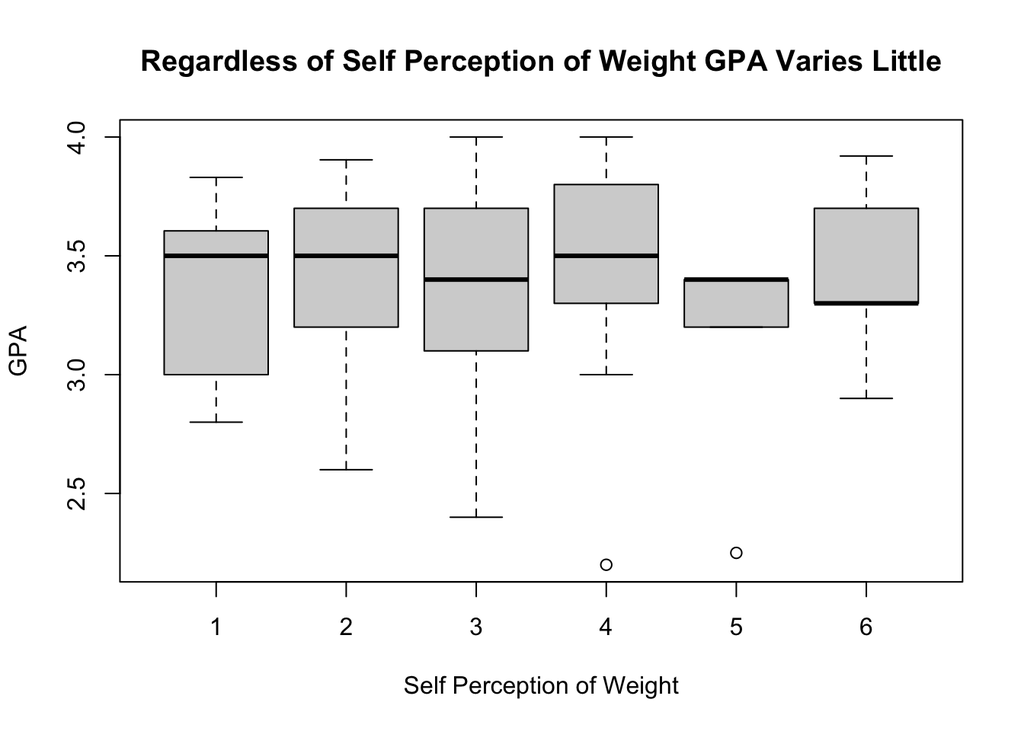

```r
# Does one's self-perception of their weight impact their GPA?
food1 %>%
boxplot(
  GPA ~ self_perception_weight,
  data = .,
  xlab = "Self Perception of Weight",
  main = "Regardless of Self Perception of Weight GPA Varies Little"
)
```

#### Dotplot

This plot allows for a clearer presentation of data congregation, or where data is heavily grouped for each factor level.

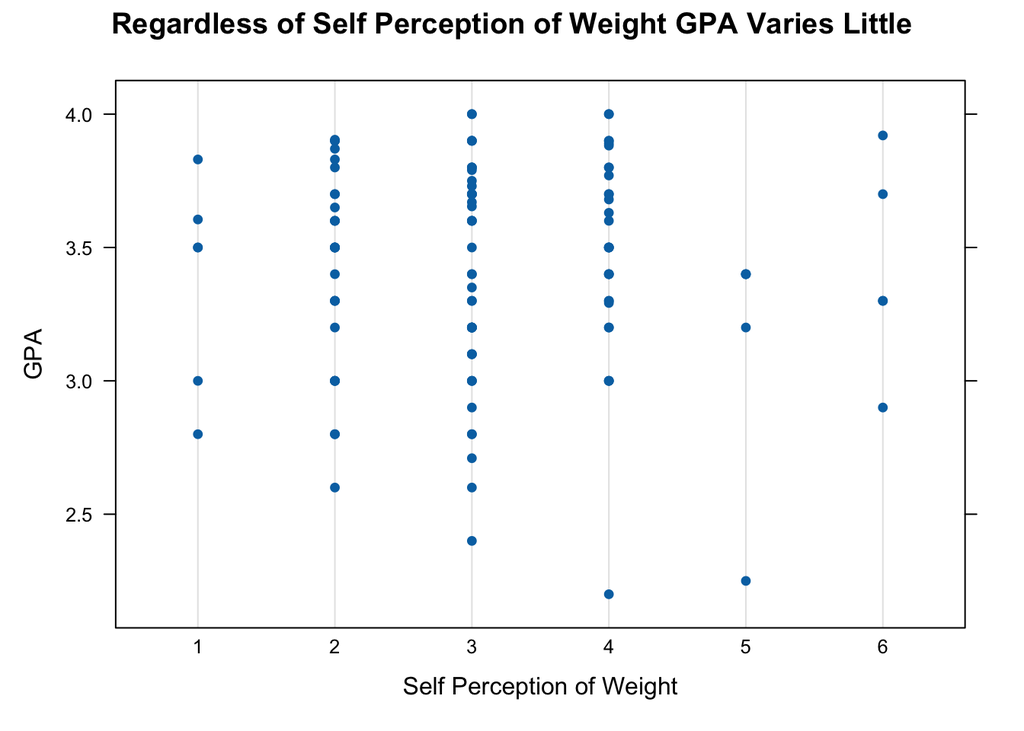

```r
# Does one's self-perception of their weight impact their GPA?
dotplot(
  GPA ~ self_perception_weight,
  data = food1,
  xlab = "Self Perception of Weight",
  main = "Regardless of Self Perception of Weight GPA Varies Little",
  na.rm = TRUE
)
```

### Statistical Test

Next, perform a **Kruskal-Wallis Rank Sum** test to assess statistical significance and display the results. Per usual, let α = 0.05 for a 95% confidence level.

```r
# Test the realtionship between GPA and self_perception_weight
test_result <-food1 %>%
  kruskal.test(GPA ~ self_perception_weight, data = .)

# test_result # Raw output
```

```r
pander(test_result) # Neat output
```

Kruskal-Wallis rank sum test: `GPA` by `self_perception_weight`

| Test statistic | df | P value |
| --- | --- | --- |
| 3.512 | 5 | 0.6216 |

It is shown in these results that the **correlation between the selected variables is low** (p-values: 0.6216). Otherwise, the resulting `GPA` values would be shown to come from significantly different distributions identifiably separate one from another by one’s `Self Perception of Weight`. However, from this test it is clear this is not likely to be the case, or in other words one’s self-perception of their own weight has little impact on their GPA.

### Numerical Summary

Lastly, a numerical summary of GPA for each of the factor levels of SPW (`self_perception_weight`) will further confirm the similarity in GPA scores even when sorted by factor level.

```r
food2 <- food1 %>%
  rename(SPW = self_perception_weight)

fvs <- food2 %>%
  favstats(GPA ~ SPW, data = .) #%>%
  # select(SPW, median) %>%


pander(fvs)
```

| SPW | min | Q1 | median | Q3 | max | mean | sd | n | missing |
| --- | --- | --- | --- | --- | --- | --- | --- | --- | --- |
| 1 | 2.8 | 3.125 | 3.5 | 3.579 | 3.83 | 3.373 | 0.3905 | 6 | 0 |
| 2 | 2.6 | 3.2 | 3.5 | 3.7 | 3.904 | 3.423 | 0.3678 | 29 | 0 |
| 3 | 2.4 | 3.1 | 3.4 | 3.7 | 4 | 3.399 | 0.4031 | 45 | 0 |
| 4 | 2.2 | 3.3 | 3.5 | 3.792 | 4 | 3.498 | 0.3843 | 30 | 0 |
| 5 | 2.25 | 3.2 | 3.4 | 3.4 | 3.4 | 3.13 | 0.4995 | 5 | 0 |
| 6 | 2.9 | 3.3 | 3.3 | 3.7 | 3.92 | 3.424 | 0.3961 | 5 | 0 |

Interestingly, when we revise the above boxplots showing key values traced across the factor levels (SPW) with lines it becomes more clear how the outliers of each level skew the mean but not the median compared to other factor levels further confirming our choice of statistical test which uses the median instead of the mean to be the more appropriate option.

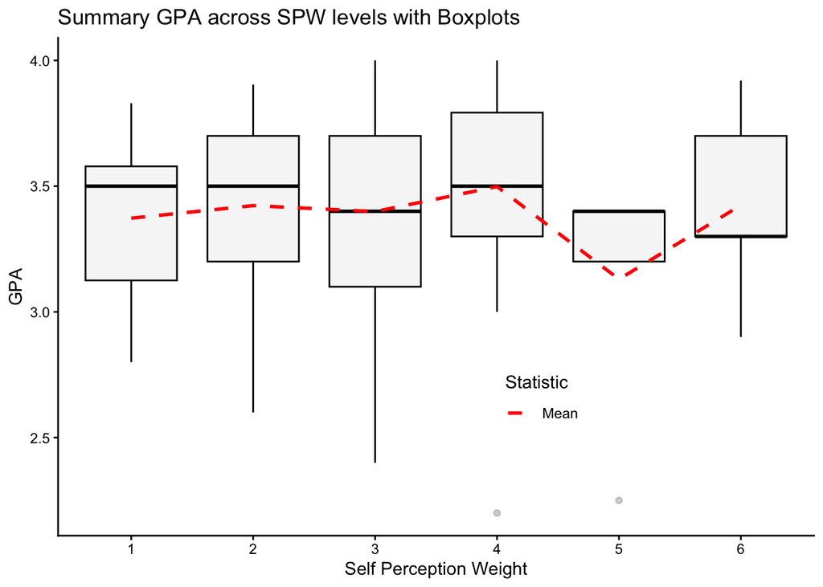

```r
ggplot() +
  # boxplots
  geom_boxplot(
    data = food2,
    aes(x = SPW, y = GPA),
    fill = "lightgray",
    color = "black",
    alpha = .2
  ) +
  # SUMMARY LINES:
  geom_line(
    data = fvs,
    aes(x = SPW, y = mean, group = 1, color = "Mean"), linetype = "dashed", linewidth = 1
  ) +
  # geom_line(
  #   data = fvs,
  #   aes(x = SPW, y = median, group = 1, color = "Median"), linetype = "solid", linewidth = 1, alpha = .7
  # ) +
  scale_color_manual(values = c("red","green"))+
  scale_x_discrete(
    labels = levels(food2$SPW)
  ) +
  labs(
    title = "Summary GPA across SPW levels with Boxplots",
    x = "Self Perception Weight",
    y = "GPA",
    color = "Statistic"
  ) +
  theme_classic()+
  theme(
    legend.position =  c(.7,.2),
    legend.justification = c("right", "bottom"),

  )
```

We could even look at the entire numerical summary as a dotplot with only the **median** and **mean** plotted with lines of course showing the same trend as above: when outliers pull on the shape of the distribution the mean follows whereas the median does so far less making it the better anchor for estimates reliant on a measure of the tendency towards centrality.

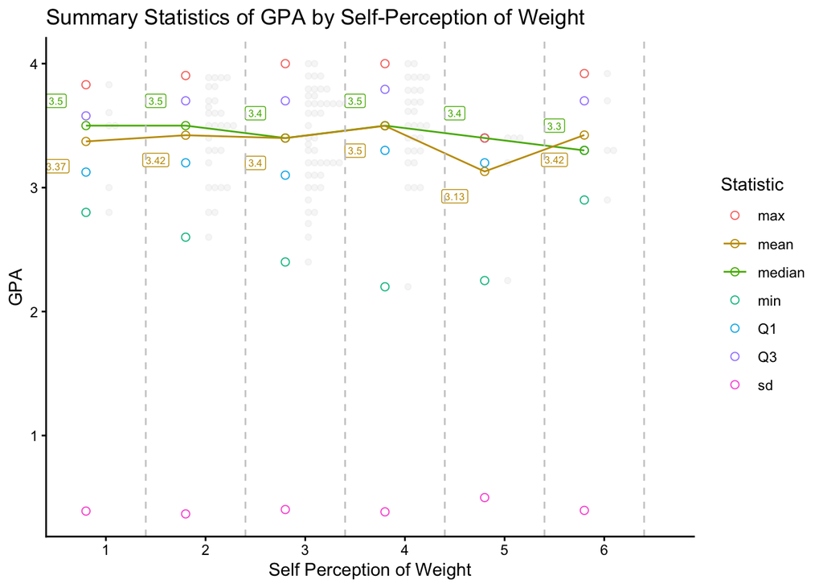

```r
# This is what the `tidyr` library was imported for.

# Elongate the data
fvs_long <- fvs %>%
  pivot_longer(cols = c(min, Q1, median, Q3, max, mean, sd),
               names_to = "Statistic",
               values_to = "Value")
# Define the negative offset for use in straightening labels and whatnot.
neg_offset <- -.2

# Primary plot
ggplot(fvs_long, aes(x = as.numeric(SPW) + neg_offset, y = Value, color = Statistic)) +
  # Dotplot: jittered value distribution
  geom_dotplot(data = food2, aes(x = SPW, y = GPA),
               binaxis = "y", stackdir = "up", fill = "gray90", color = "gray90", binwidth = 0.05, alpha = 0.3
  ) +
  # Dotplot: summary stats
  geom_point(size = 2, position = position_dodge(width = 0.0), shape = 1) +
  # Line charts: summary stats
  geom_line(data = fvs, aes(x = as.numeric(SPW) + neg_offset, y = median, color = "median")) + # Line to track the median
  geom_line(data = fvs, aes(x = as.numeric(SPW) + neg_offset, y = mean, color = "mean")) + # Line to track the mean
  # Data labels: select summary stats
  geom_label( # label: median
    data = fvs,
    aes(x = as.numeric(SPW) - .5, y = median + .2, label = round(median, digits=2), color = "median"),
    size = 2.2,
    fill = "gray100",
    show.legend = FALSE
  ) +
  geom_label( # label: mean
    data = fvs,
    aes(x = as.numeric(SPW) - .5, y = mean - .2, label = round(mean, digits=2), color = "mean"),
    size = 2.2,
    fill = "gray100",
    show.legend = FALSE
  ) +
  # Vertical line: Separate the factor levels
  geom_vline(xintercept = seq(1, 6, by = 1) + 0.4, color = "gray80", linetype = "dashed") +
  labs(
    title = "Summary Statistics of GPA by Self-Perception of Weight",
    x = "Self Perception of Weight",
    y = "GPA"
  ) +
  theme_classic()
```

### Conclusion

As discussed throughout this analysis, there appears to be **little meaningful relationship** between a person’s self-perception of their weight (`self_perception_weight`, or `SPW`) and their GPA (`GPA`). This is confirmed when examining the **median GPA values** across SPW levels, which remain relatively stable.

```r
# Max & Min 'median' (SPW levels: all)
medians <- fvs$median
min_median <- min(medians) # Lvl 6
max_median <- max(medians) # Lvl 1, 2, 4

# Median of medians (SPW levels: all)
median_of_medians <- median(medians)

# Calculate difference
diff_min <- median_of_medians - min_median
diff_max <- median_of_medians - max_median
```

For example, the median GPAs for all levels range narrowly from 3.3 to 3.5. Even the **lowest median**, found at SPW level 6 (I don’t think myself in these terms), is **3.3**, only **0.15 points below** the overall median of medians (3.45). The highest median, which is the same for SPW levels 1 (Slim), 2 (Very fit), and 4 (Slightly overweight), is **3.5**, only **-0.05 points above** the overall median of medians.

This minimal fluctuation suggests that **self-perceived weight (SPW) does not significantly influence academic performance (GPA)** in this dataset.

Further analysis could explore other variable pairings that may be more strongly correlated, or dive deeper into subgroups to assess if specific intersections (e.g., `gender` + `SPW`) reveal more nuance.